# Final Project Tutorial

Predicting Whether or Not a Book Would Be Made into a Movie: A Tutorial

By Raksha Bellary

Introduction

We've all seen some of our favorite books on the big screen. In fact, some of the most successful movies are based off of books. We're all familiar with movies like The Hunger Games, Harry Potter, The Lord of the Rings. More recently, movies like Little Women and Dune are being adapted for film. But out of so many books to choose from, what indicates whether or not a book will be chosen for a film adaptation?

We will take a look at different qualities of both books that have been made into movies and books that haven't to see if we can find a way to predict whether a book would be made into a movie or not.

First, let's import the following libraries so that we have the tools we need to get started.

```python
import pandas as pd
import numpy as np
import matplotlib.pylab as plt
import seaborn as sns
import requests
from bs4 import BeautifulSoup
import re
from sklearn.datasets import load_iris
from sklearn.tree import DecisionTreeClassifier
import sklearn.model_selection as ms
import sklearn.metrics as met
```

Data Scraping

Now, we need data, specifically data regarding "all books" (or, more realisitcally, just a lot of books) and data regarding books that were made into movies. The first CSV file below contains data from Goodreads Best Books Ever dataset (more information about it here: https://github.com/scostap/goodreads_bbe_dataset). The URLS after it redirect you to pages with lists of books that were made into movies (they are separated into different alphabetical categories).

```python
goodreads_books_data = 'https://raw.githubusercontent.com/scostap/goodreads_bbe_dataset/main/Best_Books_Ever_dataset/books_1.Best_Books_Ever.csv'
movies_from_books_09_ac = 'https://en.wikipedia.org/wiki/List_of_fiction_works_made_into_feature_films_(0%E2%80%939,_A%E2%80%93C)'
movies_from_books_dj = 'https://en.wikipedia.org/wiki/List_of_fiction_works_made_into_feature_films_(D%E2%80%93J)'
movies_from_books_kr = 'https://en.wikipedia.org/wiki/List_of_fiction_works_made_into_feature_films_(K%E2%80%93R)'
movies_from_books_sz = 'https://en.wikipedia.org/wiki/List_of_fiction_works_made_into_feature_films_(S%E2%80%93Z)'
```

Now, we will create Pandas dataframes for each dataset.

```python
goodreads_books_df = pd.read_csv(goodreads_books_data)
goodreads_books_df
```

|  | bookId | title | series | author | rating | description | language | isbn | genres | characters | ... | firstPublishDate | awards | numRatings | ratingsByStars | likedPercent | setting | coverImg | bbeScore | bbeVotes | price |
| --- | --- | --- | --- | --- | --- | --- | --- | --- | --- | --- | --- | --- | --- | --- | --- | --- | --- | --- | --- | --- | --- |
| 0 | 2767052-the-hunger-games | The Hunger Games | The Hunger Games #1 | Suzanne Collins | 4.33 | WINNING MEANS FAME AND FORTUNE.LOSING MEANS CE... | English | 9780439023481 | ['Young Adult', 'Fiction', 'Dystopia', 'Fantas... | ['Katniss Everdeen', 'Peeta Mellark', 'Cato (H... | ... | NaN | ['Locus Award Nominee for Best Young Adult Boo... | 6376780 | ['3444695', '1921313', '745221', '171994', '93... | 96.0 | ['District 12, Panem', 'Capitol, Panem', 'Pane... | https://i.gr-assets.com/images/S/compressed.ph... | 2993816 | 30516 | 5.09 |
| 1 | 2.Harry_Potter_and_the_Order_of_the_Phoenix | Harry Potter and the Order of the Phoenix | Harry Potter #5 | J.K. Rowling, Mary GrandPré (Illustrator) | 4.50 | There is a door at the end of a silent corrido... | English | 9780439358071 | ['Fantasy', 'Young Adult', 'Fiction', 'Magic',... | ['Sirius Black', 'Draco Malfoy', 'Ron Weasley'... | ... | 06/21/03 | ['Bram Stoker Award for Works for Young Reader... | 2507623 | ['1593642', '637516', '222366', '39573', '14526'] | 98.0 | ['Hogwarts School of Witchcraft and Wizardry (... | https://i.gr-assets.com/images/S/compressed.ph... | 2632233 | 26923 | 7.38 |
| 2 | 2657.To_Kill_a_Mockingbird | To Kill a Mockingbird | To Kill a Mockingbird | Harper Lee | 4.28 | The unforgettable novel of a childhood in a sl... | English | 9999999999999 | ['Classics', 'Fiction', 'Historical Fiction', ... | ['Scout Finch', 'Atticus Finch', 'Jem Finch', ... | ... | 07/11/60 | ['Pulitzer Prize for Fiction (1961)', 'Audie A... | 4501075 | ['2363896', '1333153', '573280', '149952', '80... | 95.0 | ['Maycomb, Alabama (United States)'] | https://i.gr-assets.com/images/S/compressed.ph... | 2269402 | 23328 | NaN |
| 3 | 1885.Pride_and_Prejudice | Pride and Prejudice | NaN | Jane Austen, Anna Quindlen (Introduction) | 4.26 | Alternate cover edition of ISBN 9780679783268S... | English | 9999999999999 | ['Classics', 'Fiction', 'Romance', 'Historical... | ['Mr. Bennet', 'Mrs. Bennet', 'Jane Bennet', '... | ... | 01/28/13 | [] | 2998241 | ['1617567', '816659', '373311', '113934', '767... | 94.0 | ['United Kingdom', 'Derbyshire, England (Unite... | https://i.gr-assets.com/images/S/compressed.ph... | 1983116 | 20452 | NaN |
| 4 | 41865.Twilight | Twilight | The Twilight Saga #1 | Stephenie Meyer | 3.60 | About three things I was absolutely positive.\... | English | 9780316015844 | ['Young Adult', 'Fantasy', 'Romance', 'Vampire... | ['Edward Cullen', 'Jacob Black', 'Laurent', 'R... | ... | 10/05/05 | ['Georgia Peach Book Award (2007)', 'Buxtehude... | 4964519 | ['1751460', '1113682', '1008686', '542017', '5... | 78.0 | ['Forks, Washington (United States)', 'Phoenix... | https://i.gr-assets.com/images/S/compressed.ph... | 1459448 | 14874 | 2.1 |
| ... | ... | ... | ... | ... | ... | ... | ... | ... | ... | ... | ... | ... | ... | ... | ... | ... | ... | ... | ... | ... | ... |
| 52473 | 11492014-fractured | Fractured | Fateful #2 | Cheri Schmidt (Goodreads Author) | 4.00 | The Fateful Trilogy continues with Fractured. ... | English | 2940012616562 | ['Vampires', 'Paranormal', 'Young Adult', 'Rom... | [] | ... | NaN | [] | 871 | ['311', '310', '197', '42', '11'] | 94.0 | [] | https://i.gr-assets.com/images/S/compressed.ph... | 0 | 1 | NaN |
| 52474 | 11836711-anasazi | Anasazi | Sense of Truth #2 | Emma Michaels | 4.19 | 'Anasazi', sequel to 'The Thirteenth Chime' by... | English | 9999999999999 | ['Mystery', 'Young Adult'] | [] | ... | August 3rd 2011 | [] | 37 | ['16', '14', '5', '2', '0'] | 95.0 | [] | https://i.gr-assets.com/images/S/compressed.ph... | 0 | 1 | NaN |
| 52475 | 10815662-marked | Marked | Soul Guardians #1 | Kim Richardson (Goodreads Author) | 3.70 | --READERS FAVORITE AWARDS WINNER 2011--Sixteen... | English | 9781461017097 | ['Fantasy', 'Young Adult', 'Paranormal', 'Ange... | [] | ... | March 15th 2011 | ["Readers' Favorite Book Award (2011)"] | 6674 | ['2109', '1868', '1660', '647', '390'] | 84.0 | [] | https://i.gr-assets.com/images/S/compressed.ph... | 0 | 1 | 7.37 |
| 52476 | 11330278-wayward-son | Wayward Son | NaN | Tom Pollack (Goodreads Author), John Loftus (G... | 3.85 | A POWERFUL TREMOR UNEARTHS AN ANCIENT SECRETBu... | English | 9781450755634 | ['Fiction', 'Mystery', 'Historical Fiction', '... | [] | ... | April 5th 2011 | [] | 238 | ['77', '78', '59', '19', '5'] | 90.0 | [] | https://i.gr-assets.com/images/S/compressed.ph... | 0 | 1 | 2.86 |
| 52477 | 10991547-daughter-of-helaman | Daughter of Helaman | Stripling Warrior #1 | Misty Moncur (Goodreads Author) | 4.02 | Fighting in Helaman's army is Keturah's deepes... | English | 9781599554976 | ['Lds Fiction', 'Historical Fiction', 'Young A... | [] | ... | NaN | [] | 246 | ['106', '73', '42', '17', '8'] | 90.0 | [] | https://i.gr-assets.com/images/S/compressed.ph... | 0 | 1 | 5.20 |

52478 rows × 25 columns

Creating dataframes for the books that were made into movies data requires some scraping. Then, we will merge the separate dataframes into a single dataframe for all books that were made into movies.

```python
response = requests.get(url = movies_from_books_09_ac)
html = response.content
soup = BeautifulSoup(html, 'html.parser')
```

```python
data_list = []
table = soup.find('table')
table_rows = soup.find_all('tr')

for row in table_rows:
    row_data_pts = row.find_all('td')
    row_info = [row.text.strip() for row in row_data_pts]
    if row_data_pts:
        data_list.append(row_info)
```

The following is a dataframe for books that were made into movies whose titles either begin with numbers or a letter from A through C.

```python
df_movies_ac = pd.DataFrame(data = data_list, columns = ['book', 'movie(s)'])
df_movies_ac = df_movies_ac.iloc[3:]
df_movies_ac
```

|  | book | movie(s) |
| --- | --- | --- |
| 3 | The A.B.C. Murders (1936), Agatha Christie | The Alphabet Murders (1966)The A.B.C. Murders ... |
| 4 | À ton image (1998), Louise L. Lambrichs | À ton image (2004) |
| 5 | De Aanslag (The Assault) (1982), Harry Mulisch | The Assault (1986) |
| 6 | About a Boy (1998), Nick Hornby | About a Boy (2002) |
| 7 | About Schmidt (1996), Louis Begley | About Schmidt (2002) |
| ... | ... | ... |
| 421 | Cry Wolf (a. k. a. The Demarest Inheritance) (... | Cry Wolf (1947) |
| 422 | Cutter and Bone (1976), Newton Thornburg | Cutter's Way (1981) |
| 423 | Cyborg (1972), Martin Caidin | The Six Million Dollar Man (1973) (TV) |
| 424 | Cycle of the Werewolf (1983), Stephen King | Silver Bullet (1985) |
| 425 | The Cypher (a. k. a. The Cipher) (1961), Gordo... | Arabesque (1966) |

423 rows × 2 columns

We're going to clean up the titles of the books a bit since they seem to contain publishing year and author information. For the most part, books will be easy to identify with their titles, so we will just work with that. We're also going to make the titles all lowercase in the dataframes so that they are easy to compare with our dataframe of all books later on.

```python
title_end_index = -1
for index, row in df_movies_ac.iterrows():
    if '(1' in df_movies_ac.at[index, 'book']:
        title_end_index = df_movies_ac.at[index, 'book'].index('(1')
    elif '(2' in df_movies_ac.at[index, 'book']:
        title_end_index = df_movies_ac.at[index, 'book'].index('(2')
    elif '(c.' in df_movies_ac.at[index, 'book']:
        title_end_index = df_movies_ac.at[index, 'book'].index('(c.')
    else:
        title_end_index = df_movies_ac.at[index, 'book'].index('(')
    df_movies_ac.at[index, 'book'] = (df_movies_ac.at[index, 'book'][0:title_end_index-1]).lower()

df_movies_ac
```

|  | book | movie(s) |
| --- | --- | --- |
| 3 | the a.b.c. murders | The Alphabet Murders (1966)The A.B.C. Murders ... |
| 4 | à ton image | À ton image (2004) |
| 5 | de aanslag (the assault) | The Assault (1986) |
| 6 | about a boy | About a Boy (2002) |
| 7 | about schmidt | About Schmidt (2002) |
| ... | ... | ... |
| 421 | cry wolf (a. k. a. the demarest inheritance) | Cry Wolf (1947) |
| 422 | cutter and bone | Cutter's Way (1981) |
| 423 | cyborg | The Six Million Dollar Man (1973) (TV) |
| 424 | cycle of the werewolf | Silver Bullet (1985) |
| 425 | the cypher (a. k. a. the cipher) | Arabesque (1966) |

423 rows × 2 columns

The following creates a dataframe for books that were made into movies whose titles begin with letters from D through J.

```python
response = requests.get(url = movies_from_books_dj)
html = response.content
soup = BeautifulSoup(html, 'html.parser')

data_list = []
table = soup.find('table')
table_rows = soup.find_all('tr')

for row in table_rows:
    row_data_pts = row.find_all('td')
    row_info = [row.text.strip() for row in row_data_pts]
    if row_data_pts:
        data_list.append(row_info)

df_movies_dj = pd.DataFrame(data = data_list, columns = ['book', 'movie(s)'])
df_movies_dj = df_movies_dj.iloc[2:]

title_end_index = -1
for index, row in df_movies_dj.iterrows():
    if '(1' in df_movies_dj.at[index, 'book']:
        title_end_index = df_movies_dj.at[index, 'book'].index('(1')
    elif '(2' in df_movies_dj.at[index, 'book']:
        title_end_index = df_movies_dj.at[index, 'book'].index('(2')
    elif '(c.' in df_movies_dj.at[index, 'book']:
        title_end_index = df_movies_dj.at[index, 'book'].index('(c.')
    else:
        title_end_index = df_movies_dj.at[index, 'book'].index('(')
    df_movies_dj.at[index, 'book'] = (df_movies_dj.at[index, 'book'][0:title_end_index-1]).lower()

df_movies_dj
```

|  | book | movie(s) |
| --- | --- | --- |
| 2 | the da vinci code | The Da Vinci Code (2006) |
| 3 | dad | Dad (1989) |
| 4 | damage | Damage (1992) |
| 5 | damnation alley | Damnation Alley (1977) |
| 6 | the damned utd | The Damned United (2009) |
| ... | ... | ... |
| 435 | the jungle book | Elephant Boy (1937)Jungle Book (1942)The Jungl... |
| 436 | jungle girl | Nyoka the Jungle Girl (1941-1942) (serials)Jun... |
| 437 | jupiter laughs | Shining Victory (1941)I Seek You (German: Ich ... |
| 438 | jurassic park | Jurassic Park (1993–present) (series)Jurassic ... |
| 439 | justine | Justine (1969) |

438 rows × 2 columns

The following creates a dataframe for books that were made into movies whose titles begin with letters from K through R (we're almost there...).

```python
response = requests.get(url = movies_from_books_kr)
html = response.content
soup = BeautifulSoup(html, 'html.parser')

data_list = []
table = soup.find('table')
table_rows = soup.find_all('tr')

for row in table_rows:
    row_data_pts = row.find_all('td')
    row_info = [row.text.strip() for row in row_data_pts]
    if row_data_pts:
        data_list.append(row_info)

df_movies_kr = pd.DataFrame(data = data_list, columns = ['book', 'movie(s)'])
df_movies_kr = df_movies_kr.iloc[3:]

title_end_index = -1
for index, row in df_movies_kr.iterrows():
    if '(1' in df_movies_kr.at[index, 'book']:
        title_end_index = df_movies_kr.at[index, 'book'].index('(1')
    elif '(2' in df_movies_kr.at[index, 'book']:
        title_end_index = df_movies_kr.at[index, 'book'].index('(2')
    elif '(c.' in df_movies_kr.at[index, 'book']:
        title_end_index = df_movies_kr.at[index, 'book'].index('(c.')
    else:
        title_end_index = df_movies_kr.at[index, 'book'].index('(')
    df_movies_kr.at[index, 'book'] = (df_movies_kr.at[index, 'book'][0:title_end_index-1]).lower()

df_movies_kr
```

|  | book | movie(s) |
| --- | --- | --- |
| 3 | kaitei gunkan | Atragon (1963)Super Atragon (1995) |
| 4 | kami no tsuki | Pale Moon (2014) |
| 5 | kenka erejii | Fighting Elegy (1966) |
| 6 | the keys of the kingdom | The Keys of the Kingdom (1944) |
| 7 | khamphiphaksa (the judgment) | Ai-Fak (2004) |
| ... | ... | ... |
| 408 | rum punch | Jackie Brown (1997) |
| 409 | the runaway jury | Runaway Jury (2003) |
| 410 | a running duck (a.k.a. fair game) | Cobra (1986)Fair Game (1995) |
| 411 | the running man | The Running Man (1987) |
| 412 | the russia house | The Russia House (1990) |

410 rows × 2 columns

And finally, the following creates a dataframe for books that were made into movies whose titles begin with letters from S through Z.

```python
response = requests.get(url = movies_from_books_sz)
html = response.content
soup = BeautifulSoup(html, 'html.parser')

data_list = []
table = soup.find('table')
table_rows = soup.find_all('tr')

for row in table_rows:
    row_data_pts = row.find_all('td')
    row_info = [row.text.strip() for row in row_data_pts]
    if row_data_pts:
        data_list.append(row_info)

df_movies_sz = pd.DataFrame(data = data_list, columns = ['book', 'movie(s)'])
df_movies_sz = df_movies_sz.iloc[3:]

title_end_index = -1
for index, row in df_movies_sz.iterrows():
    if '(1' in df_movies_sz.at[index, 'book']:
        title_end_index = df_movies_sz.at[index, 'book'].index('(1')
    elif '(2' in df_movies_sz.at[index, 'book']:
        title_end_index = df_movies_sz.at[index, 'book'].index('(2')
    elif '(c.' in df_movies_sz.at[index, 'book']:
        title_end_index = df_movies_sz.at[index, 'book'].index('(c.')
    else:
        title_end_index = df_movies_sz.at[index, 'book'].index('(')
    df_movies_sz.at[index, 'book'] = (df_movies_sz.at[index, 'book'][0:title_end_index-1]).lower()

df_movies_sz
```

|  | book | movie(s) |
| --- | --- | --- |
| 3 | the saga of pecos bill | Melody Time (1948)Tall Tale (1995) |
| 4 | sahara | Sahara (2005) |
| 5 | the sailor who fell from grace with the sea | The Sailor Who Fell from Grace with the Sea (1... |
| 6 | saint jack | Saint Jack (1979) |
| 7 | saint johnson | Law and Order (1932)Wild West Days (1937) |
| ... | ... | ... |
| 361 | zazie in the metro (zazie dans le métro) | Zazie in the Metro (Zazie dans le Métro) (1960) |
| 362 | de zesde mei | 06/05 (2003) |
| 363 | zona zamfirova | Zona Zamfirova (2002) |
| 364 | zorba the greek | Zorba the Greek (1964) |
| 365 | zuqāq al-midaq (midaq alley) | El callejón de los milagros (1994) |

363 rows × 2 columns

Now, we will concatenate all of our dataframes for books that were made into movies into one dataframe called movies_df.

```python
movies_df = pd.concat([df_movies_ac,
                       df_movies_dj,
                       df_movies_kr,
                       df_movies_sz],
                      ignore_index=True,
                      sort=False)
movies_df
```

|  | book | movie(s) |
| --- | --- | --- |
| 0 | the a.b.c. murders | The Alphabet Murders (1966)The A.B.C. Murders ... |
| 1 | à ton image | À ton image (2004) |
| 2 | de aanslag (the assault) | The Assault (1986) |
| 3 | about a boy | About a Boy (2002) |
| 4 | about schmidt | About Schmidt (2002) |
| ... | ... | ... |
| 1629 | zazie in the metro (zazie dans le métro) | Zazie in the Metro (Zazie dans le Métro) (1960) |
| 1630 | de zesde mei | 06/05 (2003) |
| 1631 | zona zamfirova | Zona Zamfirova (2002) |
| 1632 | zorba the greek | Zorba the Greek (1964) |
| 1633 | zuqāq al-midaq (midaq alley) | El callejón de los milagros (1994) |

1634 rows × 2 columns

The next step is to identify which books were made into movies in the dataframe containing Goodreads books data (goodreads_books_df). We will create a new column in this dataframe called "has_movie," which specifies whether a book was made into a movie (1.0) or not (0.0). As mentioned before, the title is a great identifier of a specific book for the most part, so we will iterate through the Goodreads books dataframe and cross-reference each title with the books listed in our movies dataframe. There isn't a perfect way to do this since tbe title of the same book can be written slightly differently in different datasets, so decided to go with a way that seems to be accurate for the most part (thankfully, our dataset is so large that a few mistakes won't have a huge impact): I put all the names of books that were made into movies into a single string (in lowercase, of course) and checked to see if each title in the Goodreads dataset showed up in this string.

```python
unique_movies = movies_df['book'].unique()
unique_movies_string = ''.join(unique_movies)
for index, row in goodreads_books_df.iterrows():
    if goodreads_books_df.at[index, 'title'].lower() in unique_movies_string:
        goodreads_books_df.at[index, 'has_movie'] = 1
    else:
        goodreads_books_df.at[index, 'has_movie'] = 0

goodreads_books_df
```

|  | bookId | title | series | author | rating | description | language | isbn | genres | characters | ... | awards | numRatings | ratingsByStars | likedPercent | setting | coverImg | bbeScore | bbeVotes | price | has_movie |
| --- | --- | --- | --- | --- | --- | --- | --- | --- | --- | --- | --- | --- | --- | --- | --- | --- | --- | --- | --- | --- | --- |
| 0 | 2767052-the-hunger-games | The Hunger Games | The Hunger Games #1 | Suzanne Collins | 4.33 | WINNING MEANS FAME AND FORTUNE.LOSING MEANS CE... | English | 9780439023481 | ['Young Adult', 'Fiction', 'Dystopia', 'Fantas... | ['Katniss Everdeen', 'Peeta Mellark', 'Cato (H... | ... | ['Locus Award Nominee for Best Young Adult Boo... | 6376780 | ['3444695', '1921313', '745221', '171994', '93... | 96.0 | ['District 12, Panem', 'Capitol, Panem', 'Pane... | https://i.gr-assets.com/images/S/compressed.ph... | 2993816 | 30516 | 5.09 | 1.0 |
| 1 | 2.Harry_Potter_and_the_Order_of_the_Phoenix | Harry Potter and the Order of the Phoenix | Harry Potter #5 | J.K. Rowling, Mary GrandPré (Illustrator) | 4.50 | There is a door at the end of a silent corrido... | English | 9780439358071 | ['Fantasy', 'Young Adult', 'Fiction', 'Magic',... | ['Sirius Black', 'Draco Malfoy', 'Ron Weasley'... | ... | ['Bram Stoker Award for Works for Young Reader... | 2507623 | ['1593642', '637516', '222366', '39573', '14526'] | 98.0 | ['Hogwarts School of Witchcraft and Wizardry (... | https://i.gr-assets.com/images/S/compressed.ph... | 2632233 | 26923 | 7.38 | 0.0 |
| 2 | 2657.To_Kill_a_Mockingbird | To Kill a Mockingbird | To Kill a Mockingbird | Harper Lee | 4.28 | The unforgettable novel of a childhood in a sl... | English | 9999999999999 | ['Classics', 'Fiction', 'Historical Fiction', ... | ['Scout Finch', 'Atticus Finch', 'Jem Finch', ... | ... | ['Pulitzer Prize for Fiction (1961)', 'Audie A... | 4501075 | ['2363896', '1333153', '573280', '149952', '80... | 95.0 | ['Maycomb, Alabama (United States)'] | https://i.gr-assets.com/images/S/compressed.ph... | 2269402 | 23328 | NaN | 1.0 |
| 3 | 1885.Pride_and_Prejudice | Pride and Prejudice | NaN | Jane Austen, Anna Quindlen (Introduction) | 4.26 | Alternate cover edition of ISBN 9780679783268S... | English | 9999999999999 | ['Classics', 'Fiction', 'Romance', 'Historical... | ['Mr. Bennet', 'Mrs. Bennet', 'Jane Bennet', '... | ... | [] | 2998241 | ['1617567', '816659', '373311', '113934', '767... | 94.0 | ['United Kingdom', 'Derbyshire, England (Unite... | https://i.gr-assets.com/images/S/compressed.ph... | 1983116 | 20452 | NaN | 1.0 |
| 4 | 41865.Twilight | Twilight | The Twilight Saga #1 | Stephenie Meyer | 3.60 | About three things I was absolutely positive.\... | English | 9780316015844 | ['Young Adult', 'Fantasy', 'Romance', 'Vampire... | ['Edward Cullen', 'Jacob Black', 'Laurent', 'R... | ... | ['Georgia Peach Book Award (2007)', 'Buxtehude... | 4964519 | ['1751460', '1113682', '1008686', '542017', '5... | 78.0 | ['Forks, Washington (United States)', 'Phoenix... | https://i.gr-assets.com/images/S/compressed.ph... | 1459448 | 14874 | 2.1 | 1.0 |
| ... | ... | ... | ... | ... | ... | ... | ... | ... | ... | ... | ... | ... | ... | ... | ... | ... | ... | ... | ... | ... | ... |
| 52473 | 11492014-fractured | Fractured | Fateful #2 | Cheri Schmidt (Goodreads Author) | 4.00 | The Fateful Trilogy continues with Fractured. ... | English | 2940012616562 | ['Vampires', 'Paranormal', 'Young Adult', 'Rom... | [] | ... | [] | 871 | ['311', '310', '197', '42', '11'] | 94.0 | [] | https://i.gr-assets.com/images/S/compressed.ph... | 0 | 1 | NaN | 0.0 |
| 52474 | 11836711-anasazi | Anasazi | Sense of Truth #2 | Emma Michaels | 4.19 | 'Anasazi', sequel to 'The Thirteenth Chime' by... | English | 9999999999999 | ['Mystery', 'Young Adult'] | [] | ... | [] | 37 | ['16', '14', '5', '2', '0'] | 95.0 | [] | https://i.gr-assets.com/images/S/compressed.ph... | 0 | 1 | NaN | 0.0 |
| 52475 | 10815662-marked | Marked | Soul Guardians #1 | Kim Richardson (Goodreads Author) | 3.70 | --READERS FAVORITE AWARDS WINNER 2011--Sixteen... | English | 9781461017097 | ['Fantasy', 'Young Adult', 'Paranormal', 'Ange... | [] | ... | ["Readers' Favorite Book Award (2011)"] | 6674 | ['2109', '1868', '1660', '647', '390'] | 84.0 | [] | https://i.gr-assets.com/images/S/compressed.ph... | 0 | 1 | 7.37 | 0.0 |
| 52476 | 11330278-wayward-son | Wayward Son | NaN | Tom Pollack (Goodreads Author), John Loftus (G... | 3.85 | A POWERFUL TREMOR UNEARTHS AN ANCIENT SECRETBu... | English | 9781450755634 | ['Fiction', 'Mystery', 'Historical Fiction', '... | [] | ... | [] | 238 | ['77', '78', '59', '19', '5'] | 90.0 | [] | https://i.gr-assets.com/images/S/compressed.ph... | 0 | 1 | 2.86 | 0.0 |
| 52477 | 10991547-daughter-of-helaman | Daughter of Helaman | Stripling Warrior #1 | Misty Moncur (Goodreads Author) | 4.02 | Fighting in Helaman's army is Keturah's deepes... | English | 9781599554976 | ['Lds Fiction', 'Historical Fiction', 'Young A... | [] | ... | [] | 246 | ['106', '73', '42', '17', '8'] | 90.0 | [] | https://i.gr-assets.com/images/S/compressed.ph... | 0 | 1 | 5.20 | 0.0 |

52478 rows × 26 columns

```python
goodreads_books_df[goodreads_books_df.language != 'English']
```

|  | bookId | title | series | author | rating | description | language | isbn | genres | characters | ... | awards | numRatings | ratingsByStars | likedPercent | setting | coverImg | bbeScore | bbeVotes | price | has_movie |
| --- | --- | --- | --- | --- | --- | --- | --- | --- | --- | --- | --- | --- | --- | --- | --- | --- | --- | --- | --- | --- | --- |
| 181 | 2175.Madame_Bovary | Madame Bovary | NaN | Gustave Flaubert, Mark Overstall (Contributor)... | 3.68 | 'Oh, why, dear God, did I marry him?'Emma Bova... | French | 9780192840394 | ['Classics', 'Fiction', 'France', 'Literature'... | ['Emma Bovary', 'Charles Bovary', 'Monsieur Ho... | ... | [] | 253769 | ['65316', '85529', '68711', '24294', '9919'] | 87.0 | ['Rouen (France)', "Yonville-l'Abbaye (France)... | https://i.gr-assets.com/images/S/compressed.ph... | 80572 | 1009 | 1.45 | 0.0 |
| 199 | 6350972-tote-m-dchen-l-gen-nicht | Tote Mädchen lügen nicht | NaN | Jay Asher (Goodreads Author), Knut Krüger (Übe... | 3.92 | You can’t stop the future. You can’t rewind th... | German | 9783570160206 | ['Young Adult', 'Contemporary', 'Fiction', 'Re... | ['Clay Jensen', 'Hannah Baker', 'Bryce Walker'... | ... | ['Georgia Peach Book Award Nominee for Honor b... | 772610 | ['293442', '239282', '153708', '57123', '29055'] | 89.0 | [] | https://i.gr-assets.com/images/S/compressed.ph... | 71281 | 817 | 3.86 | 0.0 |
| 309 | 40937505 | زندگی مه آلود پریا | NaN | سید مرتضی مصطفوی (Goodreads Author) | 3.92 | Mystical storyThe internal revolution of a wom... | Persian | 9786007072714 | ['Fiction'] | [] | ... | [] | 948 | ['584', '107', '47', '17', '193'] | 78.0 | [] | https://i.gr-assets.com/images/S/compressed.ph... | 39342 | 396 | NaN | 0.0 |
| 354 | 646462._ | القرآن الكريم | NaN | Anonymous | 4.35 | The Quran (English pronunciation: /kɔrˈɑːn/; A... | Arabic | 9999999999999 | ['Religion', 'Islam', 'Nonfiction', 'Classics'... | ['Moses (Bible)', 'Jesus', 'Abraham (Bible)', ... | ... | [] | 57449 | ['41757', '4582', '4587', '2616', '3907'] | 89.0 | ['Mekka and Madina (Saudi Arabia)'] | https://i.gr-assets.com/images/S/compressed.ph... | 32967 | 372 | NaN | 0.0 |
| 369 | 30528535 | انتحار فاشل | NaN | أحمد جمال الدين رمضان | 4.51 | كتاب "انتحار فاشل" عبارة عن مجموعة قصصية متنوع... | Arabic | 9789778100079 | ['Short Stories', 'Fiction', 'Anthologies', 'N... | [] | ... | [] | 2270 | ['1493', '560', '132', '47', '38'] | 96.0 | [] | https://i.gr-assets.com/images/S/compressed.ph... | 31144 | 319 | NaN | 0.0 |
| ... | ... | ... | ... | ... | ... | ... | ... | ... | ... | ... | ... | ... | ... | ... | ... | ... | ... | ... | ... | ... | ... |
| 52436 | 10830713-nie-wszystko-w-yciu | Nie wszystko w życiu | NaN | Karolina Baset | 4.67 | Nie wszystko w życiu opowiada historię kobiety... | Polish | 9788361194187 | [] | [] | ... | [] | 3 | [] | NaN | [] | https://i.gr-assets.com/images/S/compressed.ph... | 1 | 1 | NaN | 0.0 |
| 52440 | 4565266-modlitwa-o-deszcz | Modlitwa o deszcz | Terra incognita | Wojciech Jagielski | 4.33 | Modlitwa o deszcz jest owocem jedenastu podróż... | Polish | 9788374143318 | ['Nonfiction', 'Polish Literature', 'History',... | [] | ... | ['Amber Butterfly Prize (Arkady Fidler Travel ... | 395 | ['186', '158', '46', '4', '1'] | 99.0 | ['Afghanistan'] | https://i.gr-assets.com/images/S/compressed.ph... | 1 | 1 | NaN | 0.0 |
| 52454 | 13254398-au-petit-poil | Au Petit Poil | Cool and Lam #26 | A.A. Fair | 3.89 | NaN | NaN | 9782702427651 | ['Mystery', 'Fiction', 'Detective'] | ['Bertha Cool', 'Donald Lam'] | ... | [] | 96 | ['24', '42', '25', '5', '0'] | 95.0 | [] | NaN | 1 | 1 | 4.00 | 0.0 |
| 52462 | 2613071 | گل‌های معرفت | Le Cycle de l'invisible #1-3 | Éric-Emmanuel Schmitt, سروش حبیبی (Translator) | 3.56 | An alternate cover for this isbn can be found ... | Persian | 9789643621636 | ['Short Stories', 'Fiction', 'France', 'Litera... | [] | ... | [] | 656 | ['144', '214', '192', '79', '27'] | 84.0 | [] | https://i.gr-assets.com/images/S/compressed.ph... | 1 | 1 | NaN | 0.0 |
| 52464 | 36374396-algedonic | Algedonic | NaN | R.H. Sin (Goodreads Author) | 3.71 | Bestselling poet r.h. Sin, author of the Whisk... | NaN | 9781449494223 | ['Poetry', 'Nonfiction', 'Romance', 'Feminism'] | [] | ... | [] | 1489 | ['501', '402', '339', '144', '103'] | 83.0 | [] | https://i.gr-assets.com/images/S/compressed.ph... | 1 | 1 | 8.94 | 0.0 |

9817 rows × 26 columns

We'll also go ahead and make sure all the page numbers are in as float values since that seems important.

```python
for index, row in goodreads_books_df.iterrows():
    if 'page' in str(goodreads_books_df.at[index, 'pages']):
        end_of_num_index = str(goodreads_books_df.at[index, 'pages']).index('page') - 1
        goodreads_books_df.at[index, 'pages'] = str(goodreads_books_df.at[index, 'pages'])[0:end_of_num_index]
    if goodreads_books_df.at[index, 'pages'] != 'NaN' and str(goodreads_books_df.at[index, 'pages']) != 'nan':
        goodreads_books_df.at[index, 'pages'] = float(goodreads_books_df.at[index, 'pages'])
```

Exploratory Data Analysis

There are a lot of columns, so here is a list of all of them so that we can see all of them. We will choose columns that seem interesting and look into them more.

```python
goodreads_books_df.columns
```

```
Index(['bookId', 'title', 'series', 'author', 'rating', 'description',
       'language', 'isbn', 'genres', 'characters', 'bookFormat', 'edition',
       'pages', 'publisher', 'publishDate', 'firstPublishDate', 'awards',
       'numRatings', 'ratingsByStars', 'likedPercent', 'setting', 'coverImg',
       'bbeScore', 'bbeVotes', 'price', 'has_movie'],
      dtype='object')
```

Let's start by looking at the number of pages in a book.

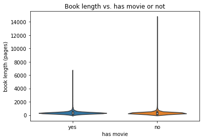

```python
page_numbers = []

for index, row in goodreads_books_df.iterrows():
    if str(goodreads_books_df.at[index, 'pages']) != 'NaN' and str(goodreads_books_df.at[index, 'pages']) != 'nan':
        if goodreads_books_df.at[index, 'has_movie'] == 1.0:
            page_numbers.append({'has_movie': 1.0, 'pages': goodreads_books_df.at[index, 'pages']})
        else:
            page_numbers.append({'has_movie': 0.0, 'pages': goodreads_books_df.at[index, 'pages']})

page_numbers = pd.DataFrame(page_numbers)
sns.violinplot(x = 'has_movie', y = 'pages', data=page_numbers, order=[1.0, 0.0])
plt.title('Book length vs. has movie or not')
plt.xlabel('has movie')
plt.xticks(range(2), ['yes', 'no'])
plt.ylabel('book length (pages)')
plt.show()
```

According to the violin plot above, there seem to be some outliers for some rather long books for both books that have and have not been made into movies, so let's remove some of these outliers from the plot to get a better sense of what the book lengths look like. We will only add a book to the plot if its length is less than or equal to 1,000 pages.

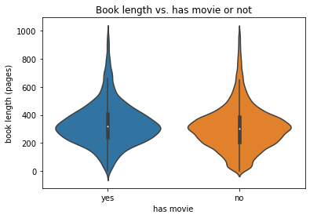

```python
page_numbers = []

for index, row in goodreads_books_df.iterrows():
    if str(goodreads_books_df.at[index, 'pages']) != 'NaN' and str(goodreads_books_df.at[index, 'pages']) != 'nan' and float(goodreads_books_df.at[index, 'pages']) <= 1000:
        if goodreads_books_df.at[index, 'has_movie'] == 1.0:
            page_numbers.append({'has_movie': 1.0, 'pages': goodreads_books_df.at[index, 'pages']})
        else:
            page_numbers.append({'has_movie': 0.0, 'pages': goodreads_books_df.at[index, 'pages']})

page_numbers = pd.DataFrame(page_numbers)
sns.violinplot(x = 'has_movie', y = 'pages', data=page_numbers, order=[1.0, 0.0])
plt.title('Book length vs. has movie or not')
plt.xlabel('has movie')
plt.xticks(range(2), ['yes', 'no'])
plt.ylabel('book length (pages)')
plt.show()
```

This plot gives us a clearer idea. As we can see, there does not seem to be any significant difference between number of pages and whether or not a book was made into a movie, so it doesn't seem to helpful for classification. Let's move on to the next quality: the percentage of Goodreads users that liked the book.

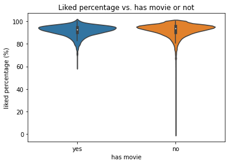

```python
liked_percentages = []

for index, row in goodreads_books_df.iterrows():
    if str(goodreads_books_df.at[index, 'likedPercent']) != 'NaN' and str(goodreads_books_df.at[index, 'likedPercent']) != 'nan':
        if goodreads_books_df.at[index, 'has_movie'] == 1.0:
            liked_percentages.append({'has_movie': 1.0, 'likedPercent': goodreads_books_df.at[index, 'likedPercent']})
        else:
            liked_percentages.append({'has_movie': 0.0, 'likedPercent': goodreads_books_df.at[index, 'likedPercent']})

liked_percentages = pd.DataFrame(liked_percentages)
sns.violinplot(x = 'has_movie', y = 'likedPercent', data=liked_percentages, order=[1.0, 0.0])
plt.title('Liked percentage vs. has movie or not')
plt.xlabel('has movie')
plt.xticks(range(2), ['yes', 'no'])
plt.ylabel('liked percentage (%)')
plt.show()
```

It seems like the percentage of users who liked the book does not have much difference (disregarding outliers, of course), so we will keep moving on. Now, let's look at the number of awards a book has won, since this seems like something that reflects its popularity (probably important).

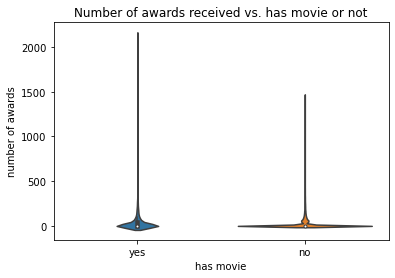

```python
num_awards = []

for index, row in goodreads_books_df.iterrows():
    if str(goodreads_books_df.at[index, 'awards']) != 'NaN' and str(goodreads_books_df.at[index, 'awards']) != 'nan':
        if goodreads_books_df.at[index, 'has_movie'] == 1.0:
            num_awards.append({'has_movie': 1.0, 'numAwards': len(list(goodreads_books_df.at[index, 'awards']))})
        else:
            num_awards.append({'has_movie': 0.0, 'numAwards': len(list(goodreads_books_df.at[index, 'awards']))})

num_awards = pd.DataFrame(num_awards)
sns.violinplot(x = 'has_movie', y = 'numAwards', data=num_awards, order=[1.0, 0.0])
plt.title('Number of awards received vs. has movie or not')
plt.xlabel('has movie')
plt.xticks(range(2), ['yes', 'no'])
plt.ylabel('number of awards')
plt.show()
```

This plot can be a lot clearer if we zoom in and disregard outliers.

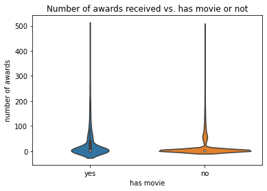

```python
num_awards = []

for index, row in goodreads_books_df.iterrows():
    if str(goodreads_books_df.at[index, 'awards']) != 'NaN' and str(goodreads_books_df.at[index, 'awards']) != 'nan' and len(list(goodreads_books_df.at[index, 'awards'])) <= 500:
        if goodreads_books_df.at[index, 'has_movie'] == 1.0:
            num_awards.append({'has_movie': 1.0, 'numAwards': len(list(goodreads_books_df.at[index, 'awards']))})
        else:
            num_awards.append({'has_movie': 0.0, 'numAwards': len(list(goodreads_books_df.at[index, 'awards']))})

num_awards = pd.DataFrame(num_awards)
sns.violinplot(x = 'has_movie', y = 'numAwards', data=num_awards, order=[1.0, 0.0])
plt.title('Number of awards received vs. has movie or not')
plt.xlabel('has movie')
plt.xticks(range(2), ['yes', 'no'])
plt.ylabel('number of awards')
plt.show()
```

It looks like books that have not been made into movies tend to have zero awards a lot more than books that have been made into movies. So we will make a new column in our dataframe that indicates whether or not a book has awards (1) or does not have any awards (0).

```python
for index, row in goodreads_books_df.iterrows():
    if str(goodreads_books_df.at[index, 'awards']) != 'NaN' and str(goodreads_books_df.at[index, 'awards']) != 'nan':
        if len(list(goodreads_books_df.at[index, 'awards'])) > 0:
            goodreads_books_df.at[index, 'has_awards'] = 1
        else:
            goodreads_books_df.at[index, 'has_awards'] = 0
```

Now, let's look at publisher information.

```python
unique_publishers = goodreads_books_df['publisher'].unique()
print("Number of unique publishers for all books:", len(unique_publishers))

has_movie_books_df = goodreads_books_df[goodreads_books_df['has_movie'] == 1.0]
unique_publishers_has_movie = has_movie_books_df['publisher'].unique()
print("Number of unique publishers for books that have movies:", len(unique_publishers_has_movie))

no_movie_books_df = goodreads_books_df[goodreads_books_df['has_movie'] == 0.0]
unique_publishers_no_movie = no_movie_books_df['publisher'].unique()
print("Number of unique publishers for books that do not have movies:", len(unique_publishers_no_movie))
```

```
Number of unique publishers for all books: 11111
Number of unique publishers for books that have movies: 911
Number of unique publishers for books that do not have movies: 10898
```

It turns out there are 11,111 unique publishers in this dataframe, but books that have movies only have 911 unique publishers while books that do not have 10,898 unique publishers. That's a big difference, so let's dive a little deeper.

```python
has_movie_books_df['publisher'].describe()
```

```
count        2061
unique        910
top       Vintage
freq           49
Name: publisher, dtype: object
```

Apparently, the top publisher among books that have movies is Vintage. The following lists the next top publishers in order for books that have movies.

```python
def remove_non_english_characters(text):
    text = re.sub("[^a-zA-Z0-9]+", "",text)
    return text

for index, row in goodreads_books_df.iterrows():
    if str(goodreads_books_df.at[index, 'publisher']) != 'NaN' and str(goodreads_books_df.at[index, 'publisher']) != 'nan':
        goodreads_books_df.at[index, 'publisher'] = remove_non_english_characters(str(goodreads_books_df.at[index, 'publisher']))
```

```python
has_movie_books_without_top_publisher_df = has_movie_books_df[has_movie_books_df.publisher != 'Vintage']
has_movie_books_without_top_publisher_df['publisher'].describe()
```

```
count              2012
unique              909
top       Penguin Books
freq                 41
Name: publisher, dtype: object
```

```python
has_movie_books_without_top_two_publishers_df = has_movie_books_without_top_publisher_df[has_movie_books_without_top_publisher_df.publisher != 'Penguin Books']
has_movie_books_without_top_two_publishers_df['publisher'].describe()
```

```
count                 1971
unique                 908
top       Ballantine Books
freq                    35
Name: publisher, dtype: object
```

```python
has_movie_books_without_top_three_publishers_df = has_movie_books_without_top_two_publishers_df[has_movie_books_without_top_two_publishers_df.publisher != 'Ballantine Books']
has_movie_books_without_top_three_publishers_df['publisher'].describe()
```

```
count              1936
unique              907
top       HarperCollins
freq                 33
Name: publisher, dtype: object
```

```python
has_movie_books_without_top_four_publishers_df = has_movie_books_without_top_three_publishers_df[has_movie_books_without_top_three_publishers_df.publisher != 'HarperCollins']
has_movie_books_without_top_four_publishers_df['publisher'].describe()
```

```
count             1903
unique             906
top       Pocket Books
freq                26
Name: publisher, dtype: object
```

```python
has_movie_books_without_top_five_publishers_df = has_movie_books_without_top_four_publishers_df[has_movie_books_without_top_four_publishers_df.publisher != 'Pocket Books']
has_movie_books_without_top_five_publishers_df['publisher'].describe()
```

```
count                 1877
unique                 905
top       Penguin Classics
freq                    23
Name: publisher, dtype: object
```

It looks like the frequency is starting to decrease a lot more from where we started, so we are going to now classify publishers that have at least 30 occurrances in books that have movies as "top publishers." Then, we will create a new column that specifies whether or not a book has a top publisher or not.

```python
top_publishers = ['vintage', 'penguin books', 'ballantine books', 'harpercollins']

for index, row in goodreads_books_df.iterrows():
    if goodreads_books_df.at[index, 'publisher'] != 'NaN' and goodreads_books_df.at[index, 'publisher'] != 'nan':
        if str(goodreads_books_df.at[index, 'publisher']).lower() in top_publishers:
            goodreads_books_df.at[index, 'has_top_publisher'] = 1
        else:
            goodreads_books_df.at[index, 'has_top_publisher'] = 0
```

Next, we will look at average star ratings. The dataframe provides data about the number of people who rated a specific book from one to 5 stars. For each book, we will calculate the average of these ratings and place it to a new column for average star ratings.

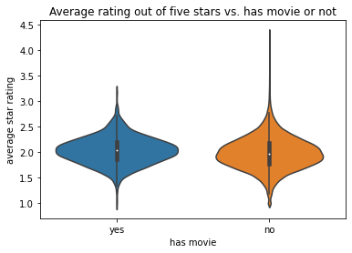

```python
avg_star_ratings = []

for index, row in goodreads_books_df.iterrows():
    ratings = []
    if str(goodreads_books_df.at[index, 'ratingsByStars']) != '[]':
        ratings_str = goodreads_books_df.at[index, 'ratingsByStars']
        ratings_str = ratings_str[1:-1].split(', ')
        for str_val in ratings_str:
            ratings.append(int(str_val[1:-1]))
        one_star_count = int(ratings[0])
        two_stars_count = int(ratings[1])
        three_stars_count = int(ratings[2])
        four_stars_count = int(ratings[3])
        five_stars_count = int(ratings[4])
        goodreads_books_df.at[index, 'avg_star_rating'] = (one_star_count * 1 + two_stars_count * 2 + three_stars_count * 3 + four_stars_count * 4 + five_stars_count * 5) / goodreads_books_df.at[index, 'numRatings']

        if goodreads_books_df.at[index, 'has_movie'] == 1.0:
            avg_star_ratings.append({'has_movie': 1.0, 'avg_star_rating': goodreads_books_df.at[index, 'avg_star_rating']})
        else:
            avg_star_ratings.append({'has_movie': 0.0, 'avg_star_rating': goodreads_books_df.at[index, 'avg_star_rating']})

avg_star_ratings = pd.DataFrame(avg_star_ratings)
sns.violinplot(x = 'has_movie', y = 'avg_star_rating', data=avg_star_ratings, order=[1.0, 0.0])
plt.title('Average rating out of five stars vs. has movie or not')
plt.xlabel('has movie')
plt.xticks(range(2), ['yes', 'no'])
plt.ylabel('average star rating')
plt.show()
```

According to this violin plot, there does not seem to be a significant difference between average star ratings for books with movies and books without. In fact, it looks like the highest average rating occurs in a book that has not been made into a movie (probably due to a low number of readers). For both types of books, the average is somewhere around 2.0 stars.

Since it seems like the number of people who interact with a book is a sign of its popularity and might help indicate whether or not has been made into a movie or not, let's now take a look at the number of ratings for each book itself.

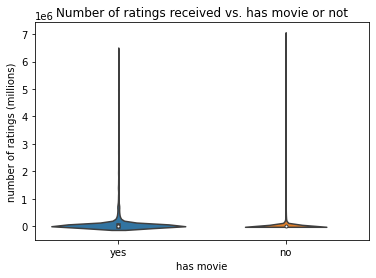

```python
num_ratings = []

for index, row in goodreads_books_df.iterrows():
    if str(goodreads_books_df.at[index, 'numRatings']) != 'NaN' and str(goodreads_books_df.at[index, 'numRatings']) != 'nan':
        if goodreads_books_df.at[index, 'has_movie'] == 1.0:
            num_ratings.append({'has_movie': 1.0, 'numRatings': int(goodreads_books_df.at[index, 'numRatings'])})
        else:
            num_ratings.append({'has_movie': 0.0, 'numRatings': int(goodreads_books_df.at[index, 'numRatings'])})

num_ratings = pd.DataFrame(num_ratings)
sns.violinplot(x = 'has_movie', y = 'numRatings', data=num_ratings, order=[1.0, 0.0])
plt.title('Number of ratings received vs. has movie or not')
plt.xlabel('has movie')
plt.xticks(range(2), ['yes', 'no'])
plt.ylabel('number of ratings (millions)')
plt.show()
```

This violin plot is a bit hard to see clearly. Let's zoom in by removing some outliers, specifically books with more than 500,000 ratings.

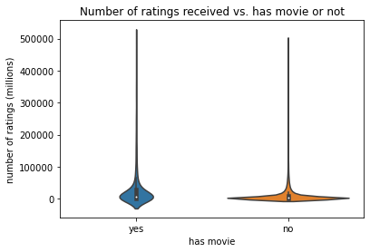

```python
num_ratings = []

for index, row in goodreads_books_df.iterrows():
    if str(goodreads_books_df.at[index, 'numRatings']) != 'NaN' and str(goodreads_books_df.at[index, 'numRatings']) != 'nan' and goodreads_books_df.at[index, 'numRatings'] <= 500000:
        if goodreads_books_df.at[index, 'has_movie'] == 1.0:
            num_ratings.append({'has_movie': 1.0, 'numRatings': int(goodreads_books_df.at[index, 'numRatings'])})
        else:
            num_ratings.append({'has_movie': 0.0, 'numRatings': int(goodreads_books_df.at[index, 'numRatings'])})

num_ratings = pd.DataFrame(num_ratings)
sns.violinplot(x = 'has_movie', y = 'numRatings', data=num_ratings, order=[1.0, 0.0])
plt.title('Number of ratings received vs. has movie or not')
plt.xlabel('has movie')
plt.xticks(range(2), ['yes', 'no'])
plt.ylabel('number of ratings (millions)')
plt.show()
```

This is a bit easier to see, but let's zoom in even more but with a box plot this time to see the averages more clearly.

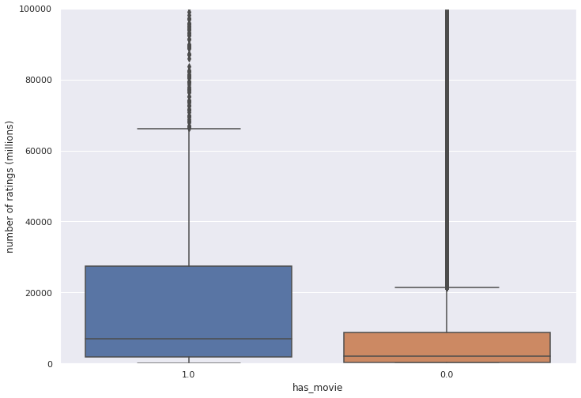

```python
sns.set(rc={'figure.figsize':(11.7,8.27)})
ax = sns.boxplot(x="has_movie", y="numRatings", data=num_ratings, order=[1.0, 0.0])
ax.set_ylabel("number of ratings (millions)")
plt.ylim(0, 100000)
plt.show()
```

This is a lot clearer, but we are going to zoom in one more time so we can really see a good split between average ratings.

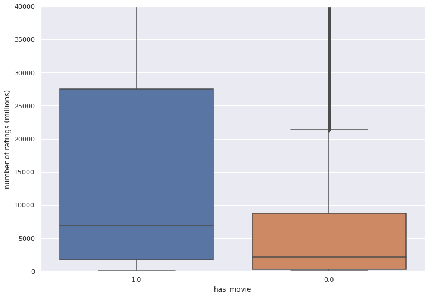

```python
sns.set(rc={'figure.figsize':(11.7,8.27)})
ax = sns.boxplot(x="has_movie", y="numRatings", data=num_ratings, order=[1.0, 0.0])
ax.set_ylabel("number of ratings (millions)")
plt.ylim(0, 40000)
plt.show()
```

According to this final box plot, it seems like having over or under 5,000 ratings is a good indicator of whether or not a book was made into a movie, so we will create a new column in our dataframe that specifies whether a book has at least 5,000 ratings (1) or not (0).

```python
for index, row in goodreads_books_df.iterrows():
    if str(goodreads_books_df.at[index, 'numRatings']) != 'NaN' and str(goodreads_books_df.at[index, 'numRatings']) != 'nan':
        if goodreads_books_df.at[index, 'numRatings'] < 5000:
            goodreads_books_df.at[index, 'has_many_ratings'] = 0
        else:
            goodreads_books_df.at[index, 'has_many_ratings'] = 1
```

Now, we are going to be taking a look at the genres for each book. Most books have more than one genre listed, so we are going to find the top genres and then graph the number of books of each type (movie and no movie) for each top genre.

```python
has_movie_unique_genres = {}
no_movie_unique_genres = {}

for index, row in goodreads_books_df.iterrows():
    genres = []
    if str(goodreads_books_df.at[index, 'genres']) == '[]':
        goodreads_books_df.at[index, 'genres'] = []
    else:
        genres_str = goodreads_books_df.at[index, 'genres']
        genres_str = genres_str[1:-1].split(', ')
        for str_val in genres_str:
            genres.append(str_val[1:-1])
        goodreads_books_df.at[index, 'genres'] = genres

        if goodreads_books_df.at[index, 'has_movie'] == 1.0:
            for genre in goodreads_books_df.at[index, 'genres']:
                if genre in has_movie_unique_genres:
                    has_movie_unique_genres[genre] += 1
                else:
                    has_movie_unique_genres[genre] = 1
        else:
            for genre in goodreads_books_df.at[index, 'genres']:
                if genre in no_movie_unique_genres:
                    no_movie_unique_genres[genre] += 1
                else:
                    no_movie_unique_genres[genre] = 1

print('Number of unique genres of books with movies:', len(has_movie_unique_genres))
print('Number of unique genres of books without movies:', len(no_movie_unique_genres))
```

```
Number of unique genres of books with movies: 494
Number of unique genres of books without movies: 979
```

Interestingly, there are 494 unique genres for books with movies and 979 (almost double!) the amount for books without movies.

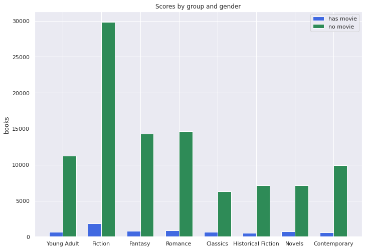

```python
top_genres_has_movie = {}
top_genres_no_movie = {}
for genre in has_movie_unique_genres:
    if has_movie_unique_genres[genre] >= 500:
        top_genres_has_movie[genre] = has_movie_unique_genres[genre]
        top_genres_no_movie[genre] = no_movie_unique_genres[genre]

top_genres = top_genres_has_movie.keys()
has_movie_genre_counts = top_genres_has_movie.values()
no_movie_genre_counts = top_genres_no_movie.values()

ind = np.arange(len(top_genres_has_movie))
width = 0.35

fig = plt.figure()
ax = fig.add_subplot(111)
rects1 = ax.bar(ind, has_movie_genre_counts, width, color='royalblue')
rects2 = ax.bar(ind+width, no_movie_genre_counts, width, color='seagreen')
ax.set_ylabel('books')
ax.set_title('Scores by group and gender')
ax.set_xticks(ind + width / 2)
ax.set_xticklabels(top_genres)

ax.legend( (rects1[0], rects2[0]), ('has movie', 'no movie') )
plt.show()
```

The plot above graphs the number of books of each type for the top genres, which we are defining as genres found in at least 500 books that have been made into movies. Since there are more books that haven't been made into movies than those that have, it makes sense that there are more occurrances of each genre for books that have not been made into movies. So, we will recreate this graph but with ratios of the specific genre to the total number of books of a certain type (movie or no movie) to get a better sense.

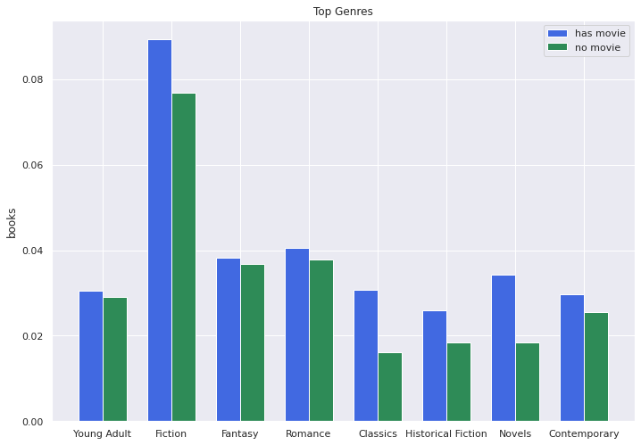

```python
top_genres_has_movie = {}
top_genres_no_movie = {}
for genre in has_movie_unique_genres:
    if has_movie_unique_genres[genre] >= 500:
        top_genres_has_movie[genre] = has_movie_unique_genres[genre] / sum(has_movie_unique_genres.values())
        top_genres_no_movie[genre] = no_movie_unique_genres[genre] / sum(no_movie_unique_genres.values())

top_genres = top_genres_has_movie.keys()
has_movie_genre_counts = top_genres_has_movie.values()
no_movie_genre_counts = top_genres_no_movie.values()

ind = np.arange(len(top_genres_has_movie))
width = 0.35

fig = plt.figure()
ax = fig.add_subplot(111)
rects1 = ax.bar(ind, has_movie_genre_counts, width, color='royalblue')
rects2 = ax.bar(ind+width, no_movie_genre_counts, width, color='seagreen')
ax.set_ylabel('books')
ax.set_title('Top Genres')
ax.set_xticks(ind + width / 2)
ax.set_xticklabels(top_genres)

ax.legend( (rects1[0], rects2[0]), ('has movie', 'no movie') )
plt.show()
```

Hypothesis Testing

Now, let's take a look at our dataframe again, but this time with all the new columns we added.

```python
goodreads_books_df.head()
```

|  | bookId | title | series | author | rating | description | language | isbn | genres | characters | ... | setting | coverImg | bbeScore | bbeVotes | price | has_movie | has_awards | has_top_publisher | avg_star_rating | has_many_ratings |
| --- | --- | --- | --- | --- | --- | --- | --- | --- | --- | --- | --- | --- | --- | --- | --- | --- | --- | --- | --- | --- | --- |
| 0 | 2767052-the-hunger-games | The Hunger Games | The Hunger Games #1 | Suzanne Collins | 4.33 | WINNING MEANS FAME AND FORTUNE.LOSING MEANS CE... | English | 9780439023481 | [Young Adult, Fiction, Dystopia, Fantasy, Scie... | ['Katniss Everdeen', 'Peeta Mellark', 'Cato (H... | ... | ['District 12, Panem', 'Capitol, Panem', 'Pane... | https://i.gr-assets.com/images/S/compressed.ph... | 2993816 | 30516 | 5.09 | 1.0 | 1.0 | 0.0 | 1.674630 | 1.0 |
| 1 | 2.Harry_Potter_and_the_Order_of_the_Phoenix | Harry Potter and the Order of the Phoenix | Harry Potter #5 | J.K. Rowling, Mary GrandPré (Illustrator) | 4.50 | There is a door at the end of a silent corrido... | English | 9780439358071 | [Fantasy, Young Adult, Fiction, Magic, Childre... | ['Sirius Black', 'Draco Malfoy', 'Ron Weasley'... | ... | ['Hogwarts School of Witchcraft and Wizardry (... | https://i.gr-assets.com/images/S/compressed.ph... | 2632233 | 26923 | 7.38 | 0.0 | 1.0 | 0.0 | 1.502097 | 1.0 |
| 2 | 2657.To_Kill_a_Mockingbird | To Kill a Mockingbird | To Kill a Mockingbird | Harper Lee | 4.28 | The unforgettable novel of a childhood in a sl... | English | 9999999999999 | [Classics, Fiction, Historical Fiction, School... | ['Scout Finch', 'Atticus Finch', 'Jem Finch', ... | ... | ['Maycomb, Alabama (United States)'] | https://i.gr-assets.com/images/S/compressed.ph... | 2269402 | 23328 | NaN | 1.0 | 1.0 | 0.0 | 1.722660 | 1.0 |
| 3 | 1885.Pride_and_Prejudice | Pride and Prejudice | NaN | Jane Austen, Anna Quindlen (Introduction) | 4.26 | Alternate cover edition of ISBN 9780679783268S... | English | 9999999999999 | [Classics, Fiction, Romance, Historical Fictio... | ['Mr. Bennet', 'Mrs. Bennet', 'Jane Bennet', '... | ... | ['United Kingdom', 'Derbyshire, England (Unite... | https://i.gr-assets.com/images/S/compressed.ph... | 1983116 | 20452 | NaN | 1.0 | 1.0 | 0.0 | 1.737820 | 1.0 |
| 4 | 41865.Twilight | Twilight | The Twilight Saga #1 | Stephenie Meyer | 3.60 | About three things I was absolutely positive.\... | English | 9780316015844 | [Young Adult, Fantasy, Romance, Vampires, Fict... | ['Edward Cullen', 'Jacob Black', 'Laurent', 'R... | ... | ['Forks, Washington (United States)', 'Phoenix... | https://i.gr-assets.com/images/S/compressed.ph... | 1459448 | 14874 | 2.1 | 1.0 | 1.0 | 0.0 | 2.400297 | 1.0 |

5 rows × 30 columns

We are now going to create a decision tree using the three categories we found to be most distinctive, has_awards, has_top_publisher, and has_many_ratings. Since we are using these columns to train our data, we will remove all rows with missing data in these columns.

```python
goodreads_books_df = goodreads_books_df[goodreads_books_df['has_awards'].notna()]
goodreads_books_df = goodreads_books_df[goodreads_books_df['has_top_publisher'].notna()]
goodreads_books_df = goodreads_books_df[goodreads_books_df['has_many_ratings'].notna()]
```

Now, we will create a dataframe from this data.

```python
ind = pd.DataFrame(goodreads_books_df, columns=['has_awards', 'has_top_publisher', 'has_many_ratings'])
print(ind.size)
ind.head()
```

```
157434
```

|  | has_awards | has_top_publisher | has_many_ratings |
| --- | --- | --- | --- |
| 0 | 1.0 | 0.0 | 1.0 |
| 1 | 1.0 | 0.0 | 1.0 |
| 2 | 1.0 | 0.0 | 1.0 |
| 3 | 1.0 | 0.0 | 1.0 |
| 4 | 1.0 | 0.0 | 1.0 |

Since the classification of whether a book has a movie or not is currently a float value, we will make a new column that has strings so that our machine learning algorithm knows does not unintentionally treat it as a continuous variable, since the output of our decision tree needs to be a category, or class (has movie or does not have movie). Our new column will have "yes" for books with movies and "no" for books without movies.

```python
for index, row in goodreads_books_df.iterrows():
    if goodreads_books_df.at[index, 'has_movie'] == 1.0:
        goodreads_books_df.at[index, 'movie'] = 'yes'
    else:
        goodreads_books_df.at[index, 'movie'] = 'no'

dep = goodreads_books_df['movie'].tolist()
```

Below is our representation of the categories as dummy variables (0/1 columns).

```python
dep_split = pd.get_dummies(dep)
dep_split
```

|  | no | yes |
| --- | --- | --- |
| 0 | 0 | 1 |
| 1 | 1 | 0 |
| 2 | 0 | 1 |
| 3 | 0 | 1 |
| 4 | 0 | 1 |
| ... | ... | ... |
| 52473 | 1 | 0 |
| 52474 | 1 | 0 |
| 52475 | 1 | 0 |
| 52476 | 1 | 0 |
| 52477 | 1 | 0 |

52478 rows × 2 columns

Now we will split the data into training and testing data. By default, the split is about 25% for testing data and 75% for training data, which sounds like a reasonable split for the size of our dataset.

```python
ind_train, ind_test, dep_train, dep_test = ms.train_test_split(ind, dep, random_state=42)
```

Below are the exact sizes of our training and testing data sets, respectfully.

```python
print("Training set size:", ind_train.size)
print("Testing set size:", ind_test.size)
```

```
Training set size: 118074
Testing set size: 39360
```

```python
dt = DecisionTreeClassifier()
dt.fit(ind_train, dep_train)
```

```
DecisionTreeClassifier()
```

Now, we will use our Decision Tree to predict the output of our testing data.

```python
predicted = dt.predict(ind_test)
predicted
```

```
array(['no', 'no', 'no', ..., 'no', 'no', 'no'], dtype='<U3')
```

```python
actual = np.array(dep_test)
predictions = np.array(predicted)
met.confusion_matrix(actual, predictions)
```

```
array([[12589,     0],
       [  531,     0]])
```

```python
print('Test accuracy =', met.accuracy_score(actual, predictions))
```

```
Test accuracy = 0.9595274390243902
```

**96% accurate!**

This seems great! Although, it seems like what really happened is our classifying decision tree played it safe by guessing "no" for our books. And to be fair, this makes sense the percentage of books that are made into movies is pretty low.

Additionally, there are so many factors that most likely play into whether or not a book is made into a movie that our data does not even begin to represent. First, Goodreads is a great place for books data, but it is not the only place that people rate or engage with books. To provide an example, Amazon Books is a pretty popular platform. Second, having connections with screenwriters or directors (or just the movie-making industry in general) could help have a book made into a movie; this may not necessarily mean being friends with them from the get-go, but it could be that already having a previous book made into a movie helps (although I would not know for sure). Finally, the content of the book itself is a very important factor that our analysis did not consider. This goes beyond genre. Within any genre, the story itself needs to be one that people want to hear, ore more accurately, see on a big screen.